# MGB data supplemental information

Tse Yang Lim

2024-04-15

### Sample size and test positivity

The full dataset contains 2671041 test results, of which 161273 are positive. Test positivity was generally under 10%, though higher during major infection waves.

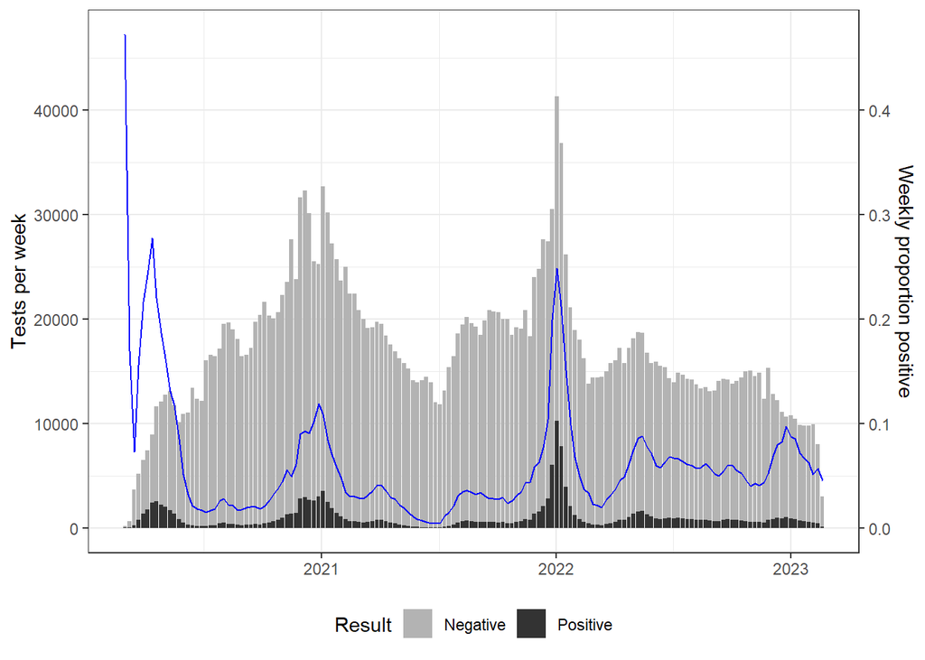

### Identifying first positive results for each case

```r
## Identify individuals with repeated positive results
rep_pos <- dat %>%
  filter(result == "Positive") %>%
  mutate(lag_person = lag(person_id), lag_date = lag(coll_date), lag_index = lag(test_index)) %>%
  mutate(is_same = case_when(person_id == lag_person ~ 1),
         days_btwn_pos = (coll_date - lag_date) * is_same) %>%
  select(-c('lag_person', 'lag_date', 'lag_index', 'is_same')) %>%
  filter(!is.na(days_btwn_pos))

## Identify putative repeat positives from same infection
short_rep_pos <- rep_pos %>%
  filter(days_btwn_pos <= 60)

## Identify potential multiple or long infections
mult_rep <- rep_pos %>%
  filter(days_btwn_pos > 60) %>%
  group_by(person_id) %>%
  summarise(count = n())
```

Among the positive test results, 25390 were non-first or repeat positives, i.e. second or subsequent positive results for a given individual. Of these repeat positives, we defined single infection episodes as comprising all consecutive positive test results for a given individual with 60 days or fewer between positive tests (regardless of any potential intervening negative test results, which we assumed were false negatives). There were 3531 individuals who had what appeared to be repeat infection episodes (with >60 days between positive results), of which 72 individuals had multiple (2 or more) repeat infection episodes thus defined. As we could not rule out long COVID or other idiosyncratic viral kinetics, we drop these 72 individuals with multiple apparent infection episodes from the final dataset.

```r
## Filter out multiple (>2) infection individuals
mult_rep <- mult_rep %>% filter(count > 1)

## Filter out imputed repeat results or long infections
dat <- dat %>%
  filter(!(person_id %in% mult_rep$person_id),  # Exclude multiple infection individuals completely
         !(sample_id %in% short_rep_pos$sample_id))  # Use sample_id to retain first positives otherwise
```

For individuals whose test results indicate only one or two infection episodes, we retained only the first positive result for each infection episode, yielding 139270 positive test results. Of these, 34736 did not report Ct values, leaving a final sample of 104534 Ct values used in this analysis.

### Sample demographics

The final sample includes results from individuals of age 0 to 90+, with most between approx. 20-75. Mean age of positive individuals varied slightly over the course of the pandemic, being slightly lower through most of 2021 and then rising across 2022-23. Approximately 55% of the positive results were from females. Weekly totals of positive results varied over the course of the pandemic, somewhat reflecting the multiple waves of infections observed more broadly (e.g. 2021 and 2022 Alpha / Omicron winter surges).

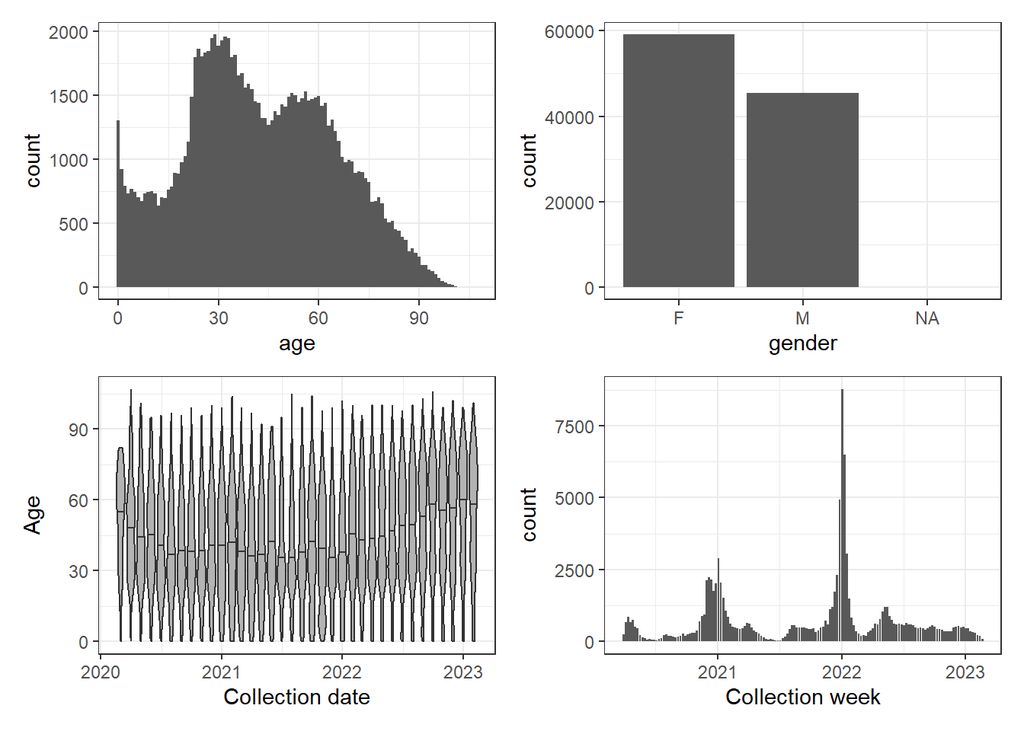

### Specimen collection & analysis

Specimens were collected from nasal and nasopharyngeal swabs (approx. 2:1 ratio), and processed using seven different RT-qPCR platform/assay combinations (BRD: Broad SARS-CoV-2, CPD: Cepheid SARS-CoV-2, CPM: Cepheid SARS-CoV-2/flu/RSV, HLF: Hologic Fusion SARS-CoV-2, RCB: Roche cobas SARS-CoV-2, RCM: Roche cobas SARS-CoV-2/flu, RLM: Roche Liat SARS-CoV-2/flu).

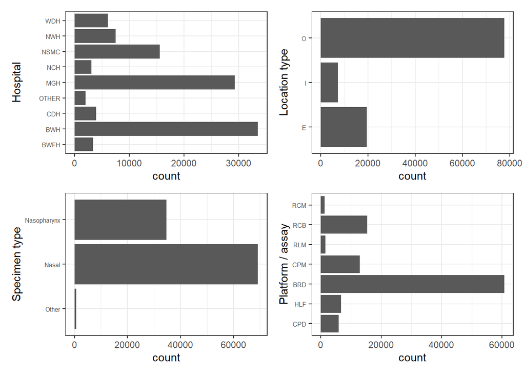